# Article: Just enough ggplot

Ben Stenhaug

# Getting started

```r
library(tidyverse)
theme_set(theme_bw(base_size = 12))
set.seed(1)
```

This website — https://ggplot2.tidyverse.org/reference/ — is incredibly useful. We’ll focus on the most basic building blocks. Let’s build a couple of data frames to use:

```r
scores <-
  tibble(
    name = c("mike", "carol", "greg", "marcia", "peter", "jan", "bobby", "cindy", "alice"),
    school = c("south", "south", "south", "south", "north", "north", "north", "south", "south"),
    teacher = c("johnson", "johnson", "johnson", "johnson",  "smith", "smith", "smith", "perry", "perry"),
    math_score = c(4, 3, 2, 4, 3, 4, 5, 4, 5),
    reading_score = c(1, 5, 2, 4, 5, 4, 1, 5, 4)
  )

random_numbers <-
    tibble(
        binom = rbinom(1000, 10, 0.5),
        pois = rpois(1000, 5)
    ) %>%
    mutate(
        mix = rnorm(1000, binom + pois, 5),
        high_low = ifelse(mix > 10, "high", "low")
    )
```

To get the basics down, I’ll show an example using the `scores` dataset and then ask you to make a similar plot using the `random_numbers` dataset.

# Plotting one variable

## geom_histogram

If your variable is continuous, you’ll want to use `geom_histogram`:

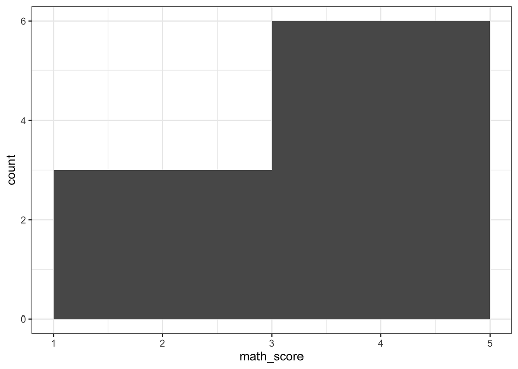

```r
scores %>%
    ggplot(aes(x = math_score)) +
    geom_histogram(binwidth = 2)
```

```r
?geom_histogram
```

Make a histogram with the random numbers and play around with `geom_histogram` options:

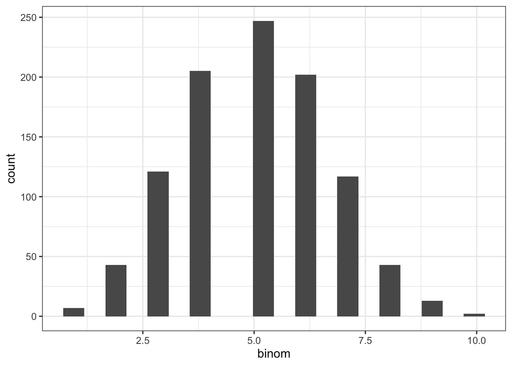

```r
random_numbers %>%
  ggplot(aes(x = binom)) +
  geom_histogram(bins = 20)
```

## geom_bar

If your variable is discrete, you’ll want to use `geom_bar`:

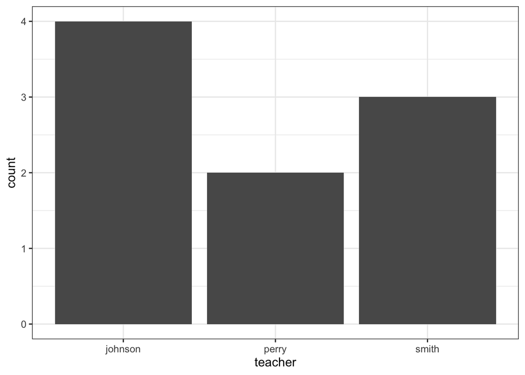

```r
scores %>%
    ggplot(aes(x = teacher)) +
    geom_bar()
```

Your turn with `geom_bar`:

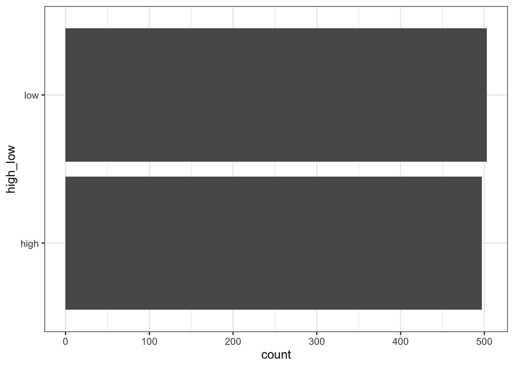

```r
random_numbers %>%
  ggplot(aes(x = high_low)) +
  geom_bar() +
  coord_flip()
```

# Plotting two variables

## geom_point

It’s most common to use a scatter plot with `geom_point`:

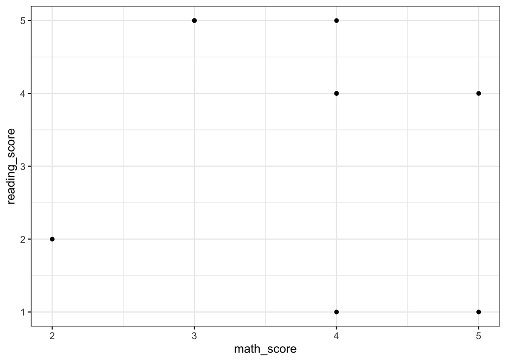

```r
scores %>%
    ggplot(aes(x = math_score, y = reading_score)) +
    geom_point()
```

You don’t have to use continuous variables!

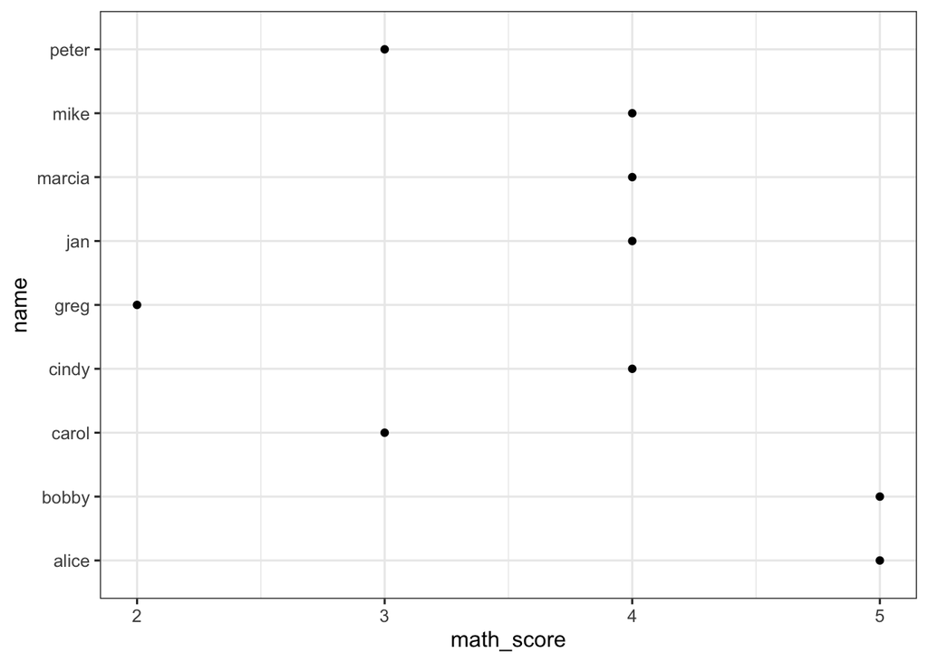

```r
scores %>%
    ggplot(aes(x = math_score, y = name)) +
    geom_point()
```

Your turn:

## geom_col

Making a column for each “point” with `geom_col` can also be useful:

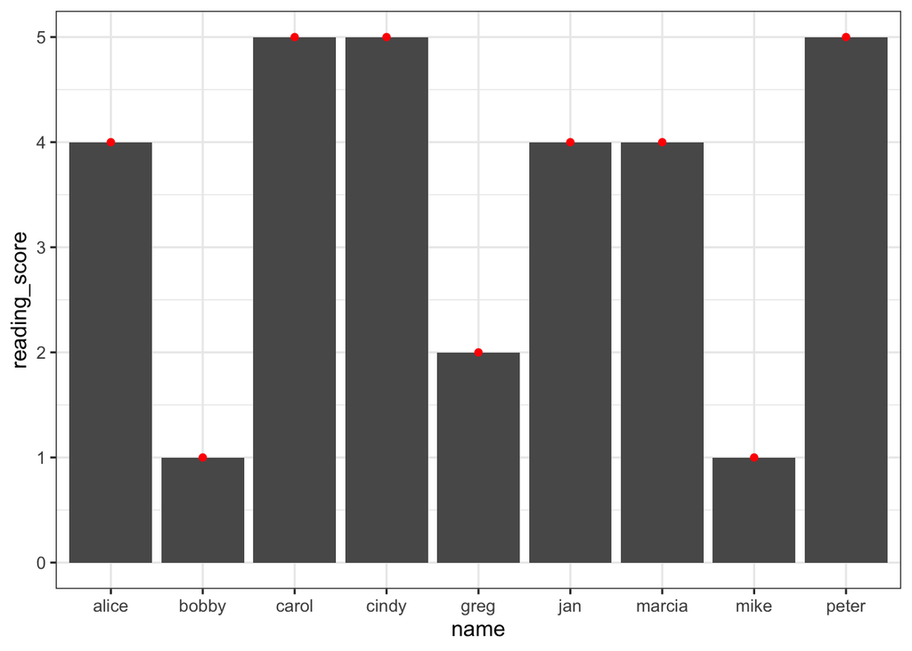

```r
scores %>%
    ggplot(aes(x = name, y = reading_score)) +
    geom_col() +
    geom_point(color = "red")
```

Your turn:

## geom_boxplot

`geom_boxplot` is useful for plotting a discrete continuous variable:

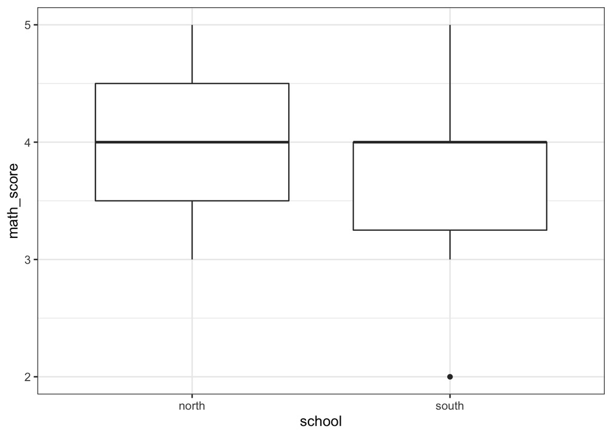

```r
scores %>%
    ggplot(aes(x = school, y = math_score)) +
    geom_boxplot()
```

Your turn:

## geom_smooth

`geom_smooth` is a fancy geom but still just uses two variables:

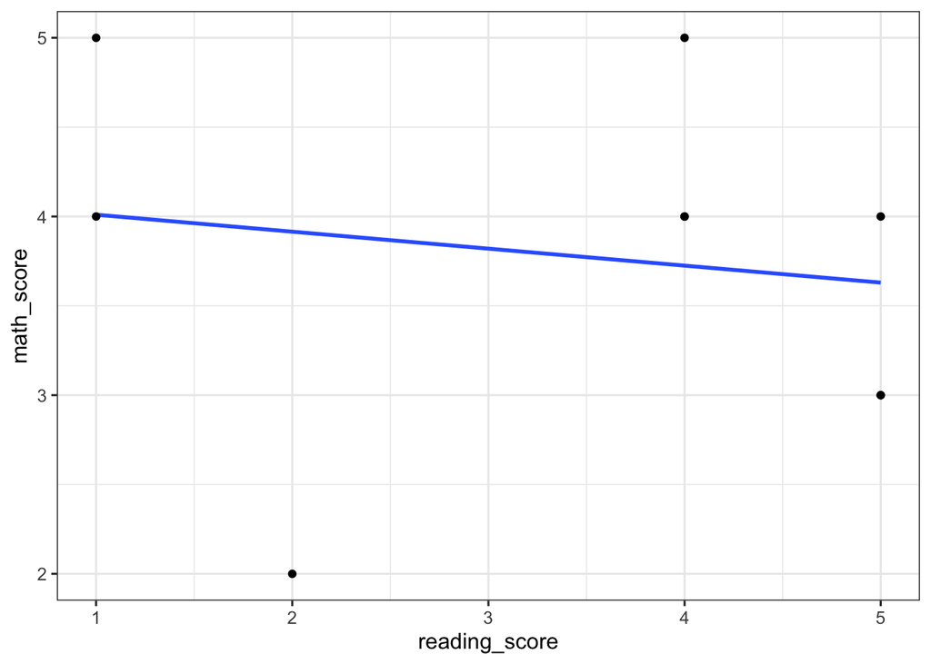

```r
scores %>% ggplot(aes(x = reading_score, y = math_score)) + geom_smooth(method = "lm", se = FALSE)  + geom_point()
```

You can have multiple geoms — in this case it’s common to point points and a smoother both on a plot.